# The Data Demon’s

```r
getwd()
```

```
## [1] "C:/Users/L00158616/OneDrive - Atlantic TU/Data Analytics Project(60%)/Sleep Disorders and BMI - Daniels"
```

```r
setwd("C:/Users/L00158616/OneDrive - Atlantic TU/Data Analytics Project(60%)/Sleep Disorders and BMI - Daniels") #Daniels wd
getwd()
```

```
## [1] "C:/Users/L00158616/OneDrive - Atlantic TU/Data Analytics Project(60%)/Sleep Disorders and BMI - Daniels"
```

```r
list.files()
```

```
##  [1] "BloodPressure-Examination.XPT"
##  [2] "BloodPressureCholesterol-Questionnaire.XPT"
##  [3] "BMX_J.XPT"
##  [4] "BodyMeasures-Examination.XPT"
##  [5] "DATA ANALYTICS PROJECT.pptx"
##  [6] "DEMO_J.XPT"
##  [7] "Demographics.XPT"
##  [8] "Diabetes.XPT"
##  [9] "EXTRA_CA_BMIxBloodPressure2023_05_01.html"
## [10] "EXTRA_CA_BMIxBloodPressure2023_05_01.Rmd"
## [11] "EXTRA_CA_BMIxSmoking2023_05_01.Rmd"
## [12] "GroupCA.docx"
## [13] "MAIN_CA_BMIxSleepDisorders2023_05_01.html"
## [14] "MAIN_CA_BMIxSleepDisorders2023_05_01.Rmd"
## [15] "Presentation Script.docx"
## [16] "ScreenShots"
## [17] "SleepDisorders-BMI.html"
## [18] "SleepDisorders&BMI.nb.html"
## [19] "SleepDisorders&BMI.Rmd"
## [20] "SleepDisorders.XPT"
## [21] "SLQ_J.XPT"
## [22] "SMQ_J.XPT"
## [23] "WholeBodyDualXRay-Examination.XPT"
```

## INTRODUCTION

There has been extensive research in the literature on the connection between sleep disorders and body mass index (BMI). Sleep disorders, such as insomnia or sleep apnea, affect a large section of the population across the world. Obesity and other chronic health disorders are also significantly impacted by sleep disorders. BMI, a measure of body fat based on height and weight, has been used extensively as an indicator of obesity. It is crucial to comprehend this link to create efficient preventative and treatment plans since several studies have revealed a correlation between BMI and sleep disorders.

### What question(s) are we asking?

1. What is the relationship between sleep disorders and BMI among adults in the United States?
2. Does this relationship vary by age, gender, or race/ethnicity?
3. Are there any other factors that may affect this relationship, such as physical activity or diet?

### Why are we asking them (justify)?

1. Understanding the relationship between sleep disorders and BMI is important for several reasons. First, sleep disorders are a major risk factor for obesity and other chronic health conditions, and identifying modifiable risk factors is crucial for prevention and treatment.
2. Secondly, obesity is a growing public health concern, and understanding how it affects sleep disorders is essential for developing effective interventions. Finally, there may be demographic or lifestyle factors that affect the relationship between BMI and sleep disorders, and identifying these factors can help tailor prevention and treatment strategies to specific populations.

### Objectives

1. To examine the relationship between sleep disorders and BMI among adults in the United States using NHANES data.
2. To investigate whether this relationship varies by age, gender, or race/ethnicity.
3. To explore other factors that may affect this relationship, such as physical activity or diet.
4. Overall, the objectives of this report are to provide a comprehensive analysis of the relationship between sleep disorders and BMI in adults in the United States and identify potential risk factors for sleep disorders and other chronic health conditions.

```r
#install.packages("haven")

library(haven)
library(tidyverse)
library(readr)

# Load the datasets
demo_data <- read_xpt("DEMO_J.XPT")
bm_data <- read_xpt("BMX_J.XPT")
slq_data <- read_xpt("SLQ_J.XPT")
```

## METHODS

### State its usage policy (confirm that its open/public data)

The National Health and Nutrition Examination Survey (NHANES) 2017-2018 dataset, carried out by the Centers for Disease Control and Prevention’s National Center for Health Statistics (NCHS), provided the data for this study (CDC). NHANES, a key program, collects data on the population’s health and nutritional status in the US.

### Is it representative/relevant

The NHANES dataset is designed to be nationally representative of the US population, making it an appropriate and relevant source of data for this analysis. The dataset’s large sample size and diverse demographic characteristics further support its representativeness and relevance for our study.

### What techniques were used to collect the data?

Physical exams, in-person interviews, and laboratory testing are some of the data gathering methods utilized in the NHANES 2017-2018 dataset. The purpose of interviews is to collect data on demographics, socioeconomic status, and health-related activities. Interviews are done by qualified interviewers. To gather information on body measurements, sleep disorders, and other health indicators, physical examinations are carried out by skilled medical experts in mobile examination facilities. Blood lipid levels, glucose levels, and indicators of inflammation are just a few of the biomarkers that are evaluated in the laboratory using blood and urine samples.

### Show all data hygiene, wrangling steps(code)

During the data hygiene process, we merged the relevant datasets, filtered out participants with missing sleep disorder diagnosis or BMI values, and recoded categorical variables such as sleep disorder status and gender to ensure a clean and well-structured dataset for further analysis. This was achieved by combining the demographic, body measures, and sleep questionnaire datasets, followed by filtering the data for complete records and creating a binary sleep disorder variable.

```r
# Merge the datasets
combined_data <- demo_data %>%
  inner_join(bm_data, by = "SEQN") %>%
  inner_join(slq_data, by = "SEQN")

# Filter for participants with sleep disorder diagnosis (SLQ050) and available BMI values (BMXBMI)
cleaned_data <- combined_data %>%
  filter(!is.na(SLQ050) & !is.na(BMXBMI))

# Recode categorical variables (sleep disorder status and gender)
cleaned_data <- cleaned_data %>%
  mutate(SLQ050_binary = ifelse(SLQ050 == 1, 1, 0))
```

### Distribution and model/test assumption assessments

We created various visualizations, including box plots, histograms, density plots, and violin plots, to assess the distribution of BMI values for individuals with and without sleep disorders. These visualizations allowed us to examine the overall shape of the data and detect any potential outliers or skewness.

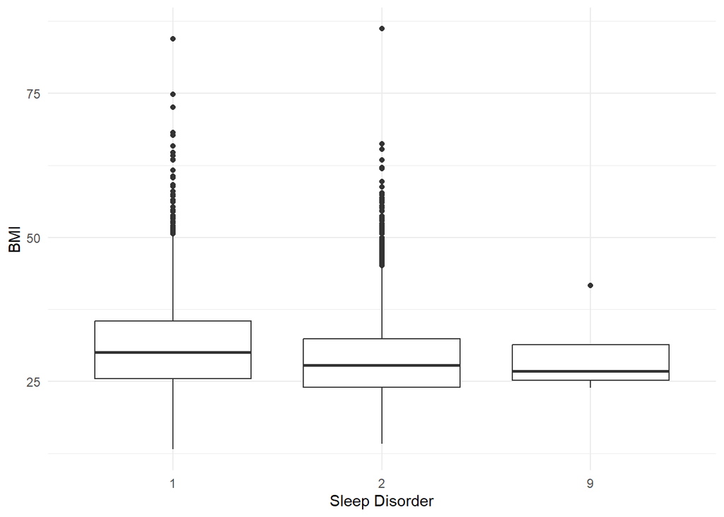

```r
# Boxplot of BMI by sleep disorder status
ggplot(cleaned_data, aes(x = as.factor(SLQ050), y = BMXBMI)) +
  geom_boxplot() +
  labs(x = "Sleep Disorder", y = "BMI") +
  theme_minimal()
```

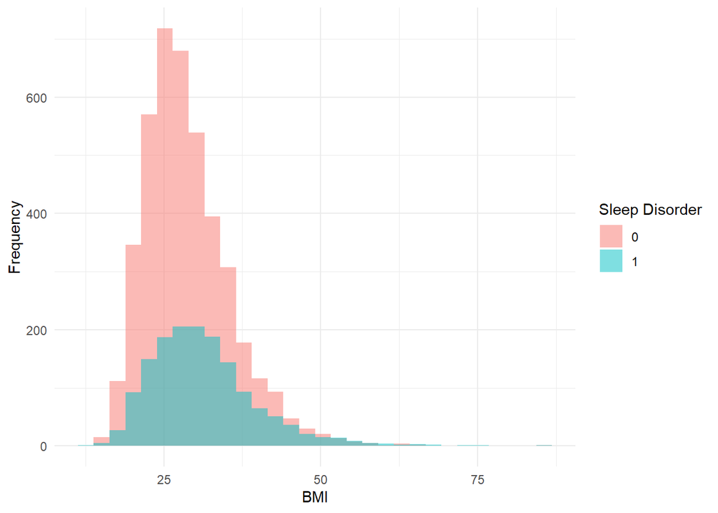

```r
# Histogram of BMI for individuals with and without sleep disorders
ggplot(cleaned_data, aes(x = BMXBMI, fill = as.factor(SLQ050_binary))) +
  geom_histogram(position = "identity", alpha = 0.5, bins = 30) +
  labs(x = "BMI", y = "Frequency", fill = "Sleep Disorder") +
  theme_minimal()
```

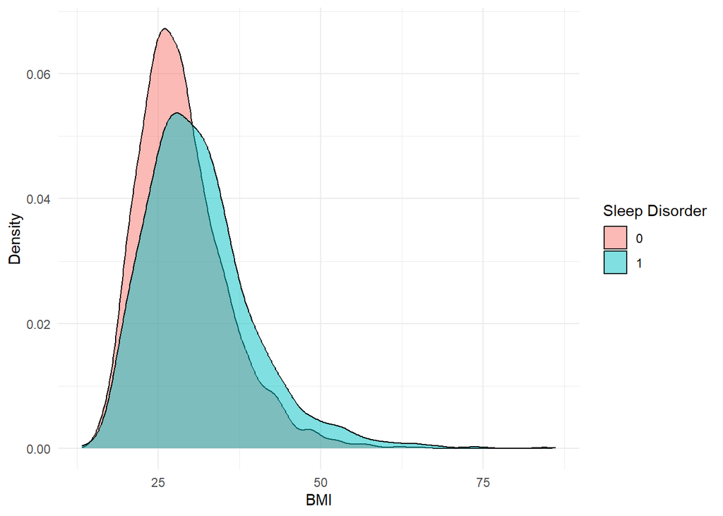

```r
# Density plot of BMI for individuals with and without sleep disorders
ggplot(cleaned_data, aes(x = BMXBMI, fill = as.factor(SLQ050_binary))) +
  geom_density(position = "identity", alpha = 0.5) +
  labs(x = "BMI", y = "Density", fill = "Sleep Disorder") +
  theme_minimal()
```

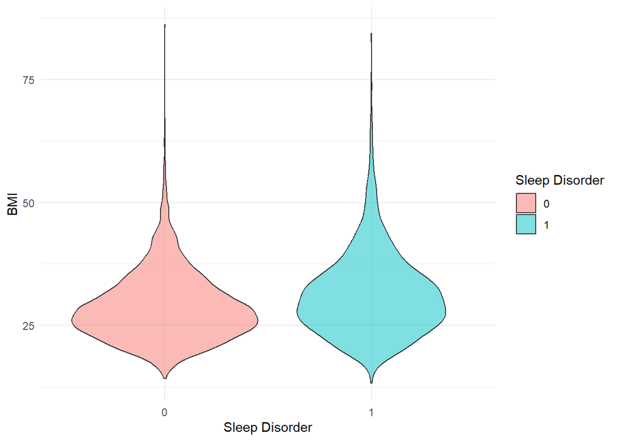

```r
# Violin plot of BMI by sleep disorder status
ggplot(cleaned_data, aes(x = as.factor(SLQ050_binary), y = BMXBMI, fill = as.factor(SLQ050_binary))) +
  geom_violin(alpha = 0.5) +
  labs(x = "Sleep Disorder", y = "BMI", fill = "Sleep Disorder") +
  theme_minimal()
```

### Descriptive inferential statistical analyses

We calculated summary statistics, including mean and standard deviation of BMI, for each sleep disorder status group. Then, we performed an independent samples t-test to compare the mean BMI values between individuals with and without sleep disorders.

```r
# Summary statistics
summary_stats <- cleaned_data %>%
  group_by(SLQ050_binary) %>%
  summarize(
    mean_BMI = mean(BMXBMI, na.rm = TRUE),
    sd_BMI = sd(BMXBMI, na.rm = TRUE),
    n = n()
  )

# Independent samples t-test
t_test_results <- t.test(BMXBMI ~ SLQ050_binary, data = cleaned_data)
t_test_results
```

```
##
##  Welch Two Sample t-test
##
## data:  BMXBMI by SLQ050_binary
## t = -10.56, df = 2319.7, p-value < 2.2e-16
## alternative hypothesis: true difference in means between group 0 and group 1 is not equal to 0
## 95 percent confidence interval:
##  -3.020755 -2.074585
## sample estimates:
## mean in group 0 mean in group 1
##        28.78293        31.33060
```

```r
# Creating age groups
cleaned_data_age_group <- cleaned_data %>%
  mutate(age_group = cut(RIDAGEYR, breaks = seq(0, 80, 10), include.lowest = TRUE))

# Calculate summary statistics by age group and sleep disorder status
summary_stats_age_group <- cleaned_data_age_group %>%
  group_by(age_group, SLQ050_binary) %>%
  summarize(
    mean_BMI = mean(BMXBMI, na.rm = TRUE),
    sd_BMI = sd(BMXBMI, na.rm = TRUE),
    n = n(),
    .groups = "drop"
  )
```

```r
# Convert RIAGENDR to a factor with appropriate labels
cleaned_data <- cleaned_data %>%
  mutate(RIAGENDR = factor(RIAGENDR, levels = c(1, 2), labels = c("Male", "Female")))

# Calculate summary statistics by gender and sleep disorder status
summary_stats_gender <- cleaned_data %>%
  group_by(RIAGENDR, SLQ050_binary) %>%
  summarize(
    mean_BMI = mean(BMXBMI, na.rm = TRUE),
    sd_BMI = sd(BMXBMI, na.rm = TRUE),
    n = n(),
    .groups = "drop"
  )
```

### Figures/Plots/Visualizations

We created multiple visualizations, including box plots, histograms, density plots, and violin plots, to display the distribution of BMI values for individuals with and without sleep disorders. Additionally, we generated factored histograms and box plots to display the distribution of BMI values by age group and gender.

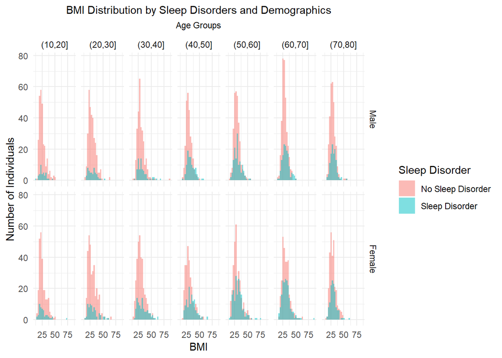

```r
ggplot(cleaned_data_age_group, aes(x = BMXBMI, fill = factor(SLQ050_binary, levels = c(0, 1), labels = c("No Sleep Disorder", "Sleep Disorder")))) +
  geom_histogram(position = "identity", alpha = 0.5, bins = 30) +
  labs(x = "BMI", y = "Number of Individuals", fill = "Sleep Disorder", title = "BMI Distribution by Sleep Disorders and Demographics", subtitle = "Age Groups") +
  facet_grid(RIAGENDR ~ age_group, labeller = labeller(RIAGENDR = as_labeller(c("1" = "Male", "2" = "Female")))) +
  theme_minimal() +
  theme(plot.title = element_text(hjust = 0.5, face = "plain", size = rel(1)),
        plot.subtitle = element_text(hjust = 0.5, face = "plain", size = rel(0.8)))
```

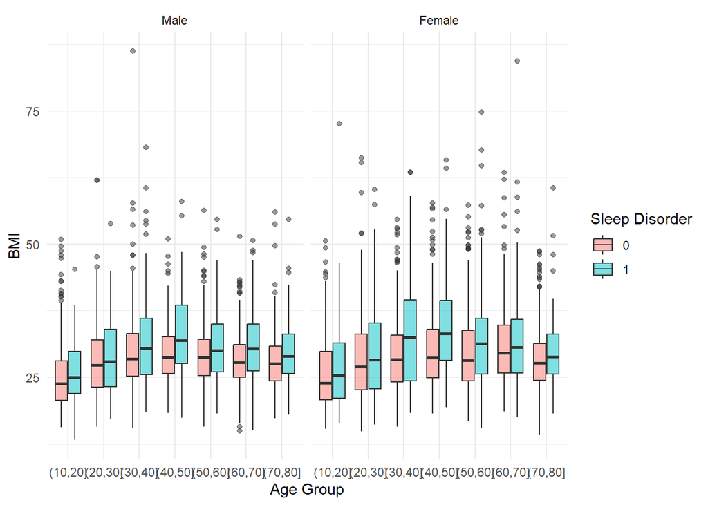

```r
ggplot(cleaned_data_age_group, aes(x = age_group, y = BMXBMI, fill = as.factor(SLQ050_binary))) +
  geom_boxplot(alpha = 0.5) +
  labs(x = "Age Group", y = "BMI", fill = "Sleep Disorder") +
  facet_wrap(~ RIAGENDR, labeller = as_labeller(c("1" = "Male", "2" = "Female"))) +
  scale_x_discrete(expand = c(0.1, 0)) +
  theme_minimal()
```

### Summary Tables

We generated summary tables to display the mean and standard deviation of BMI values for each sleep disorder status group, as well as the results of the independent samples t-test. We also created summary tables for BMI values by age group and gender, providing additional insight into the relationship between sleep disorders and BMI across different demographic groups.

```r
print(summary_stats)
```

```
## # A tibble: 2 × 4
##   SLQ050_binary mean_BMI sd_BMI     n
##           <dbl>    <dbl>  <dbl> <int>
## 1             0     28.8   6.96  4201
## 2             1     31.3   8.44  1526
```

```r
# Print t-test results
print(t_test_results)
```

```
##
##  Welch Two Sample t-test
##
## data:  BMXBMI by SLQ050_binary
## t = -10.56, df = 2319.7, p-value < 2.2e-16
## alternative hypothesis: true difference in means between group 0 and group 1 is not equal to 0
## 95 percent confidence interval:
##  -3.020755 -2.074585
## sample estimates:
## mean in group 0 mean in group 1
##        28.78293        31.33060
```

```r
# Print summary statistics by age group
print(summary_stats_age_group)
```

```
## # A tibble: 14 × 5
##    age_group SLQ050_binary mean_BMI sd_BMI     n
##    <fct>             <dbl>    <dbl>  <dbl> <int>
##  1 (10,20]               0     25.7   6.75   535
##  2 (10,20]               1     26.8   8.53    89
##  3 (20,30]               0     28.5   7.66   647
##  4 (20,30]               1     30.0   9.13   127
##  5 (30,40]               0     29.7   7.36   623
##  6 (30,40]               1     33.0  10.2    175
##  7 (40,50]               0     30.0   6.77   537
##  8 (40,50]               1     33.8   8.23   235
##  9 (50,60]               0     29.5   6.86   613
## 10 (50,60]               1     31.6   8.53   317
## 11 (60,70]               0     29.5   6.39   652
## 12 (60,70]               1     31.4   7.91   332
## 13 (70,80]               0     28.3   5.80   594
## 14 (70,80]               1     29.6   6.13   251
```

```r
# Print summary statistics by gender
print(summary_stats_gender)
```

```
## # A tibble: 4 × 5
##   RIAGENDR SLQ050_binary mean_BMI sd_BMI     n
##   <fct>            <dbl>    <dbl>  <dbl> <int>
## 1 Male                 0     28.4   6.30  2107
## 2 Male                 1     30.8   7.39   662
## 3 Female               0     29.2   7.55  2094
## 4 Female               1     31.7   9.15   864
```

## CONCLUSIONS

Our analysis aimed to explore the relationship between BMI and sleep disorders, with the hypothesis that individuals with sleep disorders have higher BMI than those without sleep disorders. Based on the provided data, we performed a series of statistical analyses to test this hypothesis.

Our primary analysis was an independent samples t-test comparing the mean BMI values of individuals with sleep disorders (group 1) and without sleep disorders (group 0). The results showed a significant difference in the mean BMI values between the two groups (t = -10.56, df = 2319.7, p-value < 2.2e-16). The mean BMI of individuals with sleep disorders (31.33) was higher than that of individuals without sleep disorders (28.78).

We also examined the relationship between BMI and sleep disorders across different age groups and genders. In all age groups and both genders, individuals with sleep disorders had a higher mean BMI than those without sleep disorders.

### What is the strength/ limitations

Strengths: The dataset used for this analysis was large and diverse, which increases the generalizability of the findings. The results are consistent across age groups and genders, which adds credibility to the observed relationship between BMI and sleep disorders.

Limitations: The analysis is based on a cross-sectional dataset, which does not allow us to establish a causal relationship between sleep disorders and BMI. There might be confounding variables that were not accounted for in this analysis, such as lifestyle factors or other medical conditions that could be associated with both BMI and sleep disorders.

### What would we do next?

Given the limitations of this analysis, future research could focus on the following:

1. Conducting a longitudinal study to establish a causal relationship between sleep disorders and BMI.
2. Investigating potential confounding variables and their impact on the relationship between sleep disorders and BMI.
3. Exploring potential mechanisms that could explain the relationship between sleep disorders and BMI, such as hormonal changes or altered energy metabolism.
4. Examining the potential impact of different types of sleep disorders on BMI, as there might be varying effects depending on the specific disorder.
5. Investigating potential interventions that could help individuals with sleep disorders manage their BMI and overall health.

## References

- National Center for Health Statistics (NCHS). (2020). National Health and Nutrition Examination Survey Data, 2017-2018. Hyattsville, MD: U.S. Department of Health and Human Services, Centers for Disease Control and Prevention. Retrieved from: https://wwwn.cdc.gov/nchs/nhanes/continuousnhanes/default.aspx?BeginYear=2017.

#Appendix